# Most of the data manipulatipon have been made through excel.

# Residuals don't obey linearity assumptions. We should check for nonlinear relations between EXCH and other variables.

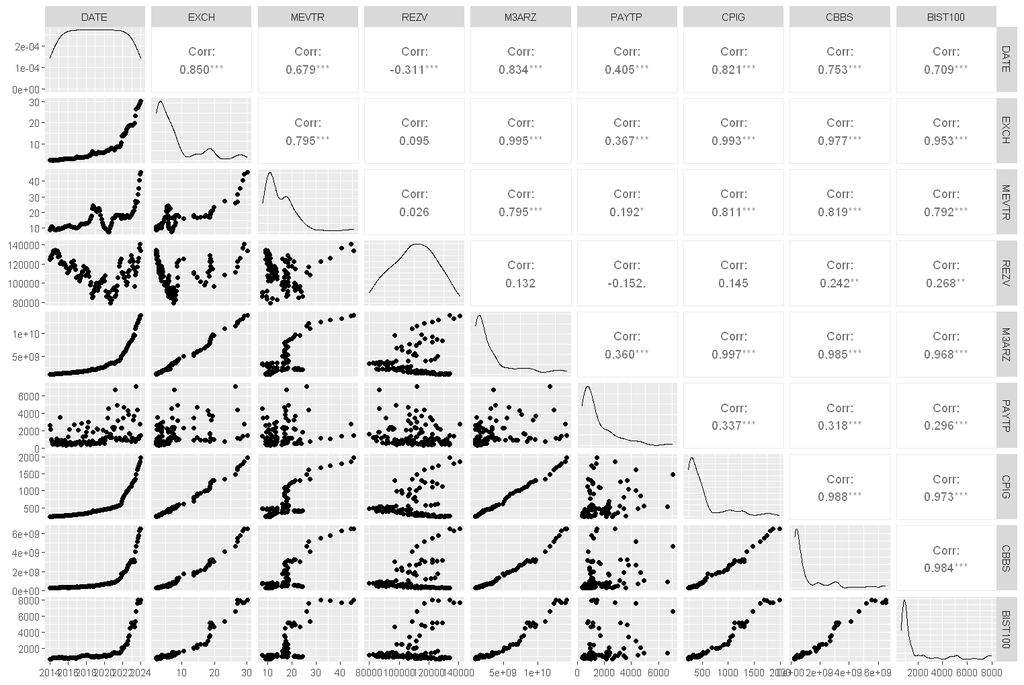

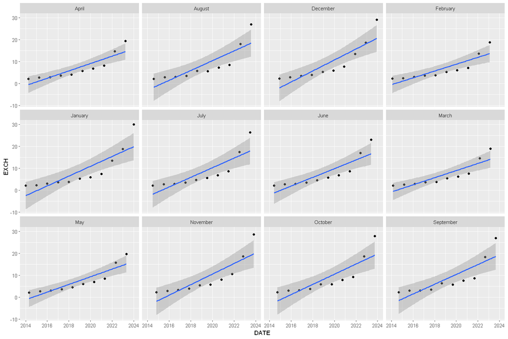

```r
exchange_rate$month_name <- month.name[month(exchange_rate$DATE)] #Although there seems to be no seasonality, we add categorical month variables for checking EXCH within the months just in case
ggpairs(exchange_rate[, !names(exchange_rate) %in% "month_name"])
ggplot(exchange_rate,aes(x=DATE,y=EXCH)) +    #Checking for any irregularities within the same months of the years
  geom_point() + geom_smooth(method=lm,linewidth=1) + facet_wrap(~month_name)
```

# EXCH seems to be increasing exponentially to the time, so we need to add its logarithmic transformation and continue improving our model based on it

# Also, we need to add the logarithmic transformations of every variable that the original EXCH has a linear relationship with since we will continue with log_EXCH

```r
nlin_exchange_rate <- copy(exchange_rate)
nlin_exchange_rate$log_EXCH <- log(exchange_rate$EXCH)
nlin_exchange_rate$log_CBBS <- log(exchange_rate$CBBS)
nlin_exchange_rate$log_CPIG <- log(exchange_rate$CPIG)
nlin_exchange_rate$log_M3ARZ <- log(exchange_rate$M3ARZ)
```

```r
nl_fit = lm(log_EXCH~.,data=nlin_exchange_rate)
nl_fit
summary(nl_fit)
```

```
Call:
lm(formula = log_EXCH ~ ., data = nlin_exchange_rate)

Coefficients:
        (Intercept)                 DATE                 EXCH
         -1.813e+01           -3.884e-05            7.622e-02
              MEVTR                 REZV                M3ARZ
          5.724e-03           -1.885e-06           -1.604e-10
              PAYTP                 CPIG                 CBBS
         -4.960e-06           -2.690e-04            3.634e-12
            BIST100     month_nameAugust   month_nameDecember
          1.751e-05           -2.434e-03            7.358e-03
 month_nameFebruary    month_nameJanuary       month_nameJuly
          1.221e-02            1.057e-02           -1.388e-02
     month_nameJune      month_nameMarch        month_nameMay
         -9.473e-03            8.882e-03           -6.512e-03
 month_nameNovember    month_nameOctober  month_nameSeptember
          1.045e-02            6.288e-03           -9.733e-04
           log_CBBS             log_CPIG            log_M3ARZ
         -4.442e-02            2.522e-01            9.301e-01
```

```
Call:
lm(formula = log_EXCH ~ ., data = nlin_exchange_rate)

Residuals:
      Min        1Q    Median        3Q       Max
-0.070137 -0.015022  0.001789  0.011868  0.068669

Coefficients:
                      Estimate Std. Error t value Pr(>|t|)
(Intercept)         -1.813e+01  1.718e+00 -10.549  < 2e-16 ***
DATE                -3.884e-05  4.373e-05  -0.888   0.3766
EXCH                 7.622e-02  8.509e-03   8.957 2.39e-14 ***
MEVTR                5.724e-03  9.282e-04   6.168 1.60e-08 ***
REZV                -1.885e-06  7.283e-07  -2.589   0.0111 *
M3ARZ               -1.604e-10  2.666e-11  -6.019 3.13e-08 ***
PAYTP               -4.960e-06  2.510e-06  -1.976   0.0510 .
CPIG                -2.690e-04  2.434e-04  -1.105   0.2719
CBBS                 3.634e-12  4.330e-11   0.084   0.9333
BIST100              1.751e-05  1.123e-05   1.559   0.1222
month_nameAugust    -2.434e-03  1.272e-02  -0.191   0.8486
month_nameDecember   7.358e-03  1.307e-02   0.563   0.5747
month_nameFebruary   1.221e-02  1.238e-02   0.986   0.3265
month_nameJanuary    1.057e-02  1.226e-02   0.862   0.3907
month_nameJuly      -1.388e-02  1.259e-02  -1.103   0.2729
month_nameJune      -9.473e-03  1.247e-02  -0.760   0.4494
month_nameMarch      8.882e-03  1.253e-02   0.709   0.4800
month_nameMay       -6.512e-03  1.239e-02  -0.526   0.6003
month_nameNovember   1.045e-02  1.285e-02   0.813   0.4181
month_nameOctober    6.288e-03  1.273e-02   0.494   0.6224
month_nameSeptember -9.733e-04  1.258e-02  -0.077   0.9385
log_CBBS            -4.442e-02  1.036e-01  -0.429   0.6689
log_CPIG             2.522e-01  1.986e-01   1.270   0.2072
log_M3ARZ            9.301e-01  1.610e-01   5.777 9.17e-08 ***
---
Signif. codes:  0 '***' 0.001 '**' 0.01 '*' 0.05 '.' 0.1 ' ' 1

Residual standard error: 0.02714 on 97 degrees of freedom
Multiple R-squared:  0.999,	Adjusted R-squared:  0.9987
F-statistic:  4091 on 23 and 97 DF,  p-value: < 2.2e-16
```

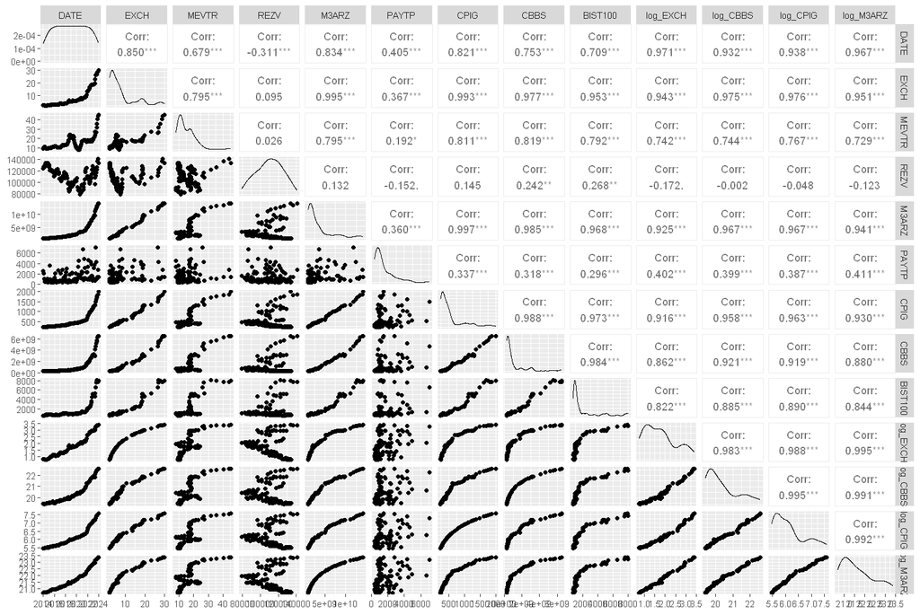

```r
ggpairs(nlin_exchange_rate[, !names(nlin_exchange_rate) %in% "month_name"])
```

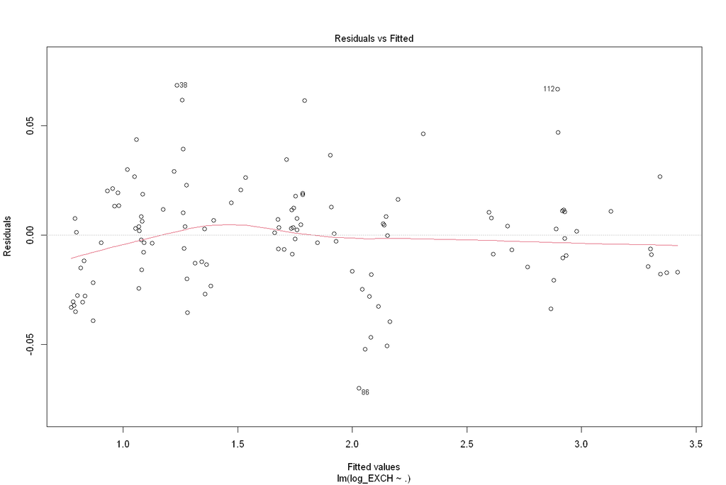

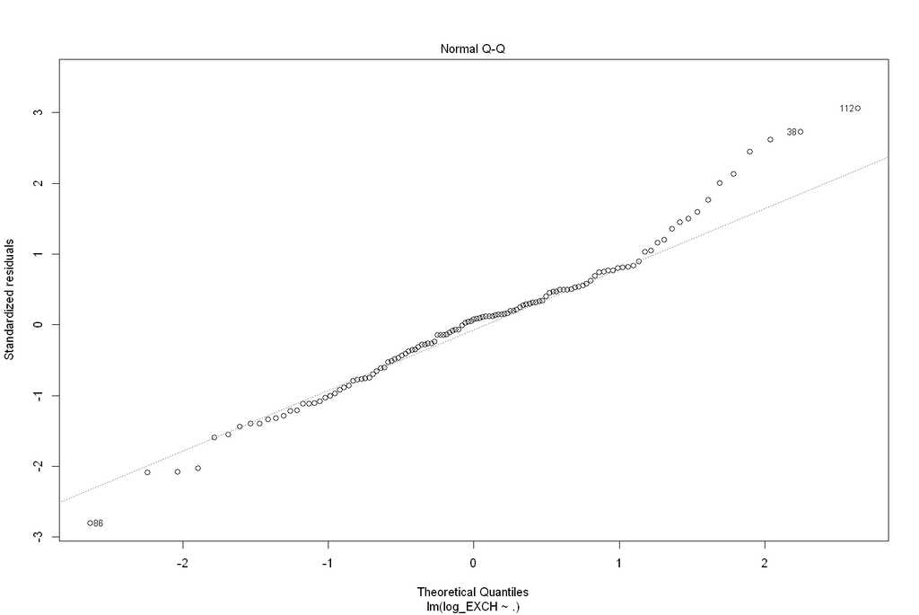

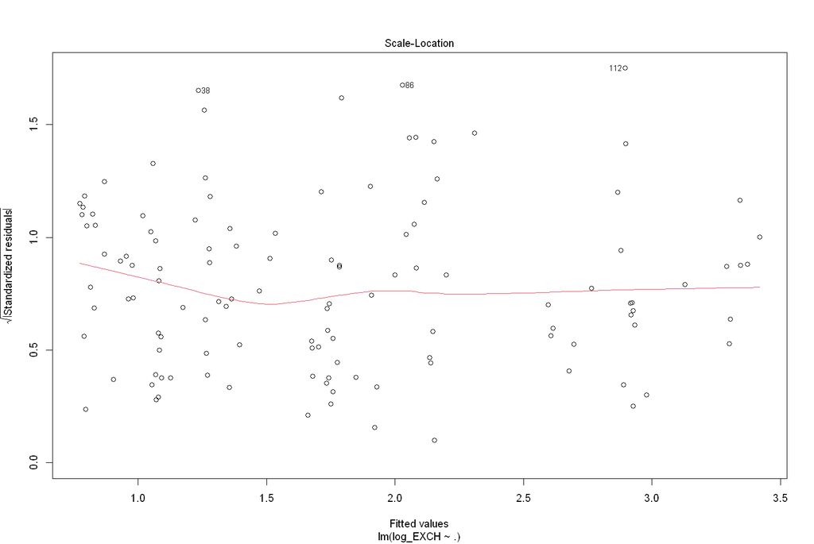

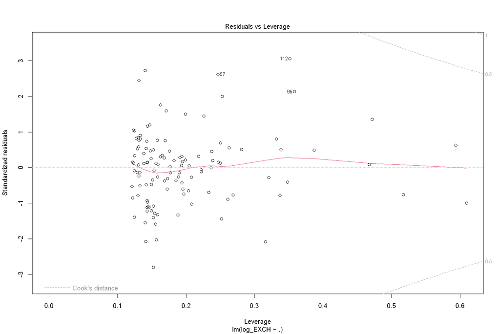

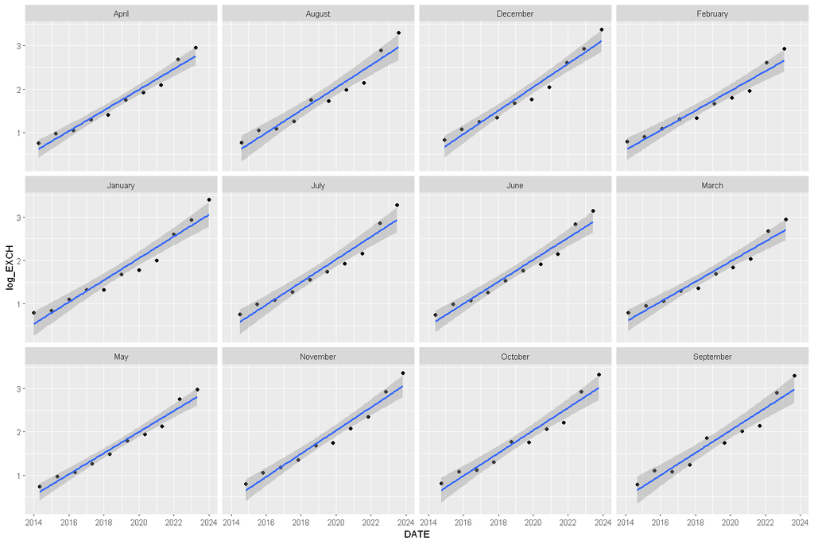

```r
plot(nl_fit)
ggplot(nlin_exchange_rate,aes(x=DATE,y=log_EXCH)) +    #Checking for any irregularities within the same months of the years
  geom_point() + geom_smooth(method=lm,linewidth=1) + facet_wrap(~month_name)
```